# Data Science Applied to Ag - Final Project - Design

Author

Charles Bency Appolon

# 1 Instructions

This file contains both the **instructions** for the mid-term project and placeholders for your code. You are required to use this file to produce code, output, and answers to the questions below.

Besides simply creating output, make sure to interpret the output. You will need to create tables and/or plots to arrive at the answers, and then comment on what you found below it.

To get you setup, you will need to:

- Student #1: create a repository on your GitHub account. You can call this repository “2025dsa_finalproject_groupX”, **where X is the number of your group**. Make it public, add a README, add a .gitignore for R.
- Student #1: follow the steps we did in class to start a new RStudio project with version control.
- Student #1: in your computer, create the sub-folders code, data, output, and move your data set into the `data` folder. Also, student 1 moves this current script into the `code` folder. Do a git stage, commit, push.
- Student #1: on GitHub, go the repository settings and invite your partner to be a collaborator in the repository. That will give them push permission.
- Now, both students should clone this repository on their computers like we did in class. Make sure this step works well and that you can pull and push from GitHub.
- Student 2, after cloning, does a git pull to get all these updates on their computer.
- Student 1 and 2 work together to update the README file. README files should explain what the repository is about, the goals of that project, who is working in it, and any other important details you may find.

# 2 Introduction

Describe here the introduction of your problem. Consider this as a shortened version of your paper, where you will briefly discuss in 3-4 paragraphs what is the issue/gap in literature, and how the data you collected will help answer this gap.  
The persistence of Escherichia coli (E. coli) on fresh produce remains a significant concern for food safety, particularly in the context of biological soil amendments of animal origin (BSAAO). Organic fertilizers, while improving soil health and sustainability, may inadvertently introduce or support the survival of enteric pathogens like E. coli in the agroecosystem. Despite the implementation of recommended pre-harvest intervals, evidence suggests that certain soil conditions or management practices may extend pathogen survival, potentially compromising produce safety.

Current literature has primarily focused on the initial contamination routes and general trends in pathogen decline. However, there remains a gap in understanding how specific soil amendments, environmental conditions, and spatial variability (e.g., location) interact to influence the survival of E. coli. In particular, limited data are available on how amendments like poultry litter or composted materials affect pathogen reduction across time and space, under real-world field conditions.

To address this gap, we conducted a field experiment evaluating E. coli populations in soil amended with different treatments and monitored over time across multiple locations. The study design incorporates key variables such as amendment type, sampling day, and field location to provide a comprehensive view of how these factors contribute to E. coli persistence.

The insights generated from this study can inform both scientific understanding and risk assessment models used by regulatory agencies. Ultimately, they support the development of more refined, evidence-based guidelines for pre-harvest intervals and soil management practices in produce production systems.

# 3 Hypothesis and objectives

Describe here your hypothesis, followed by your objectives. Make sure your hypothesis are testable and bold, and objectives are clear.

**Hypothesis**: The type of soil amendment significantly influences the survival of E. coli in soil, and this effect is modulated by time and location.

**Objectives**:

To evaluate the impact of different soil amendments on E. coli population dynamics over time.

To assess how field location contributes to variability in E. coli survival across amendment types.

To determine whether there is a significant interaction between amendment, location, and sampling day in influencing E. coli persistence in the soil.

# 4 Material and Methods

Describe here your overall material and methods as it pertains to the analysis you will conduct, including study description, site/setup description, what equipment was used, etc. just like you would in a paper. Make sure to clearly explain what was measured and how. **Inoculum Preparation**: A rifampin-resistant E. coli strain (TVS 353) was cultured and prepared to a final concentration of 1.0 × 10⁸ CFU/mL in buffered peptone water (BPW) for field inoculation. Enumeration was confirmed using TSA-R plates.

**Plot Inoculation**: Soil samples were collected on 10 timepoints (days 0 to 140) from the top 5 cm layer. Each sample (~100 g) was composited from five subsamples and processed on the same day.

**Bacterial Enumeration**: Soil E. coli levels were quantified using spread plating on TSA-R (incubated at 42°C), and MPN was used when counts fell below detection limits. Confirmation was done by streaking MPN cultures on TSA-R.

**Soil Physicochemical Analysis**: Soil was analyzed at each timepoint for:

Potassium: Extracted with 1 M KCl, shaken, and stored at -30°C. Ammonia & Nitrate: Measured using an Ammonia Analyzer after KCl extraction. Electrical Conductivity: Measured with a calibrated conductivity meter in a 1:5 soil-to-water slurry. pH and Nutrient Analysis: Oven-dried and ground soil was analyzed for nutrients via Mehlich extraction and ICP-OES. pH measurements and C/N analysis were also performed.

## 4.1 Study design

Clearly describe your study design here, including treatment design (which factors and levels, the hierarchy among them, etc.), and your experimental design (number of reps/blocks, how was randomization performed, etc.), as we talked about in class.

The factors were:

Fixed Factors:

Treatment (ammendment): three levels (use of heat-treated poultry pellets, use of poultry litter, and no amendments) applied.

Location (location): Florida and Georgia

Time (Day): Represents the time points at which measurements were taken (0, 1, 3, 7, 14, 28, 56, 84, 112, 140).

Random factor: Plot-id (rep_am) - replication = 3.

A complete randomization design was followed, and treatments were attributed accordingly.

## 4.2 Statistical analysis

Describe here your statistical analysis, including what type of ANOVA model you ran (based on the design above), what was your response variable, what were your explanatory variables and how were the explanatory variables treated (random or fixed). Provide your alpha level. Explain which function from which package you used to analyze this data. Explain how you checked linear model assumptions and whether or not they were met. Overall, make sure you explain in sufficient detail that, if given your data, a knowledgeable person would be able to reproduce your analysis exactly.

In this study, a repeated measures linear mixed effects ANOVA was conducted to examine the effects of amendment types, location, and time (day) on the log-transformed population of E. coli (or MPN) as the response variable.

Assumptions Checked: Normality: Residuals were assessed via Q-Q plots.

Homogeneity of Variance: Checked with residual plots .

# 5 Results

Here is where the coding is going to happen, and it will be completely up to you. Include under this section as many sub-sections (using ##) and as many chunks needed to create the analytical workflow for your analysis, starting at loading packages and data, wrangling, EDA, modeling, assumptions checking, ANOVA table, means, pairwise comparisons, and final publication-quality plot.

Make sure to run a model that reflects your study design. Even if your study design does not include one of the designs covered in class, you are still expected to run the most appropriate model. If you need help for references, let me know.

Before each chunk, describe the steps being performed in that chunk. For example, “Here I will load the data”.

If a chunk produces output, like printing a data frame, statistical summary, a plot, ANOVA table, etc., make sure to write text interpreting what you see and how you can/will use that information to move forward to the next steps in the workflow.  
We are loading our packages here

```r
# Load packages
library(readxl)
library(ggplot2)
library(lme4)
library(Matrix)
library(nlme)
library(dplyr)
library(emmeans)
library(multcomp)# for letter display
library(car)
library(readxl)
# Plot diagnostics
library(ggplot2)
library(patchwork)
library(broom.mixed)
```

Here, I will load the data and do some wrangling

```r
# Read in the data file
ecoli <- read_excel("../data/FL, GA_soil_ec_bothlocations.xlsx") %>%
  mutate(across(c(day, rep_am, ammendment, location), as.factor))

data <- read_excel("../data/FL,GA_commonnutrient.xls") %>%
  mutate(across(c(rep_no, day, rep_am, ammendment, location), as.factor)) %>%
  left_join(
    ecoli %>%
      dplyr::select(location, day, rep_am, ammendment, count),
    by = c("location", "day", "rep_am", "ammendment")
  )

summary(data)
```

```
 location      day     ammendment rep_no     rep_am          pH
 FL:90    0      :18   HPP:60     1:60   hpp1fl : 10   Min.   :5.050
 GA:90    1      :18   PC :60     2:60   hpp1ga : 10   1st Qu.:5.815
          3      :18   PL :60     3:60   hpp2fl : 10   Median :6.110
          7      :18                     hpp2ga : 10   Mean   :6.211
          14     :18                     hpp3fl : 10   3rd Qu.:6.643
          28     :18                     hpp3ga : 10   Max.   :7.670
          (Other):72                     (Other):120
       K                  Mg                Mn                P
 Min.   :  0.0858   Min.   :  0.523   Min.   : 0.0093   Min.   :  0.11
 1st Qu.: 58.0326   1st Qu.: 48.938   1st Qu.: 7.9566   1st Qu.: 59.83
 Median : 94.4254   Median : 63.305   Median :12.4442   Median : 93.76
 Mean   :138.5188   Mean   : 69.793   Mean   :14.7490   Mean   :125.86
 3rd Qu.:158.3883   3rd Qu.: 82.003   3rd Qu.:17.6153   3rd Qu.:176.01
 Max.   :808.7500   Max.   :188.774   Max.   :83.1797   Max.   :616.73

       Zn                N                 EC                SM
 Min.   : 0.0659   Min.   :0.03200   Min.   :0.00000   Min.   : 0.500
 1st Qu.: 3.7777   1st Qu.:0.06250   1st Qu.:0.02469   1st Qu.: 3.400
 Median : 4.8933   Median :0.07500   Median :0.10000   Median : 5.100
 Mean   : 5.8555   Mean   :0.08014   Mean   :0.15412   Mean   : 6.118
 3rd Qu.: 6.5650   3rd Qu.:0.09325   3rd Qu.:0.10000   3rd Qu.: 7.725
 Max.   :41.2614   Max.   :0.18300   Max.   :1.20000   Max.   :17.500

       Ca               count
 Min.   :   2.744   Min.   :-0.2400
 1st Qu.: 498.339   1st Qu.: 0.9035
 Median : 574.204   Median : 3.3700
 Mean   : 615.988   Mean   : 3.0591
 3rd Qu.: 700.097   3rd Qu.: 4.7955
 Max.   :1610.675   Max.   : 7.0700
```

```r
# Split data by location
data_fl <- data %>% filter(location == "FL") %>% mutate(ammendment = relevel(ammendment, ref = "PC"))
data_ga <- data %>% filter(location == "GA") %>% mutate(ammendment = relevel(ammendment, ref = "PC"))
```

Here, we do exploratory overview of all the response variable.

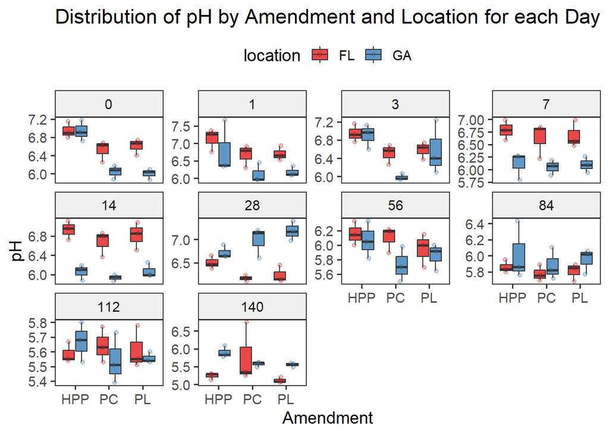

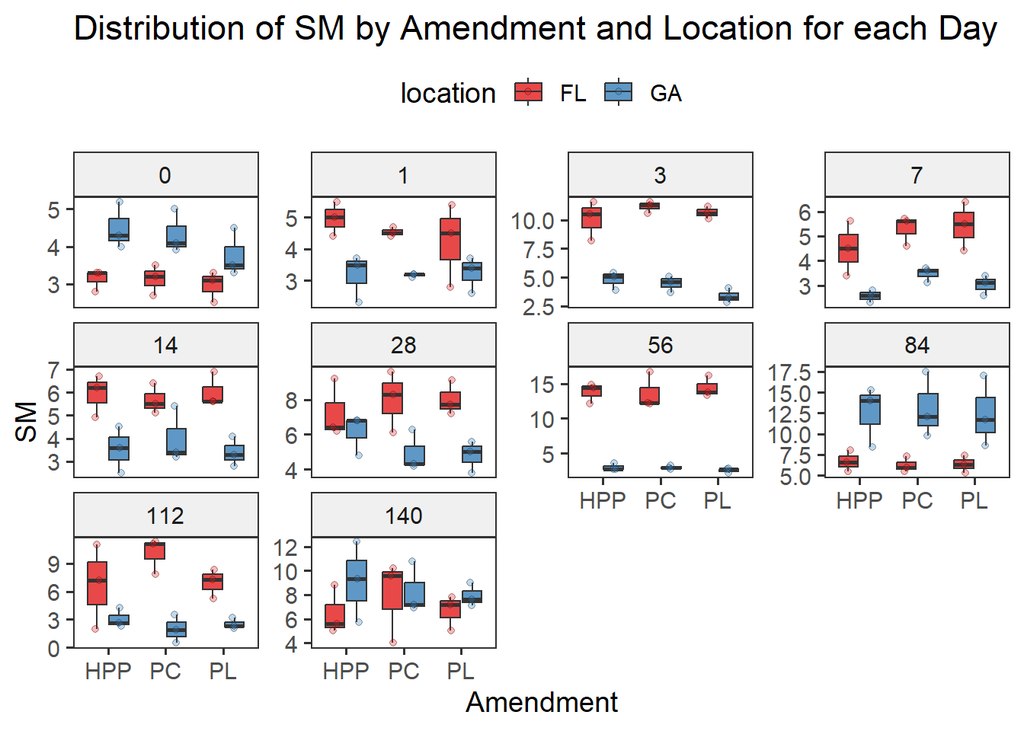

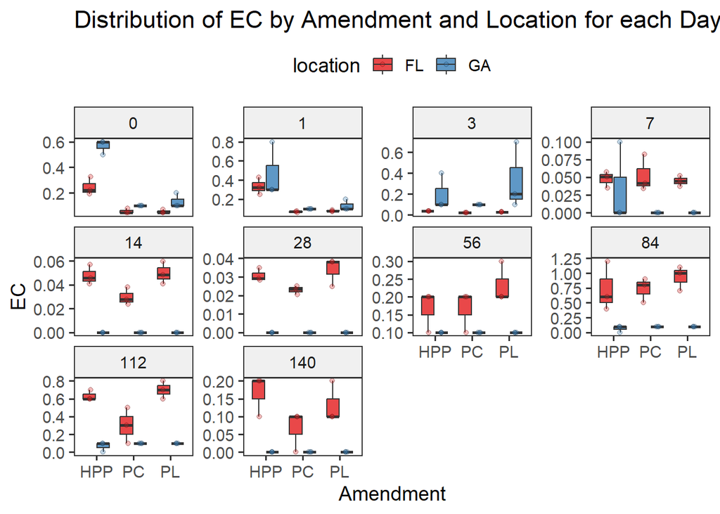

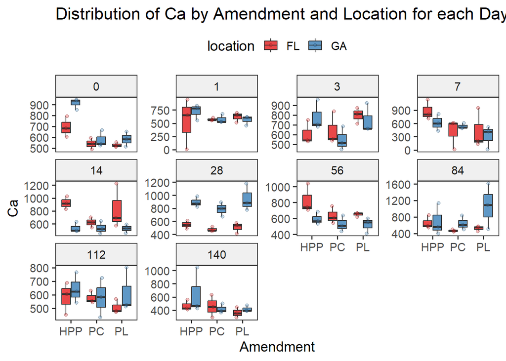

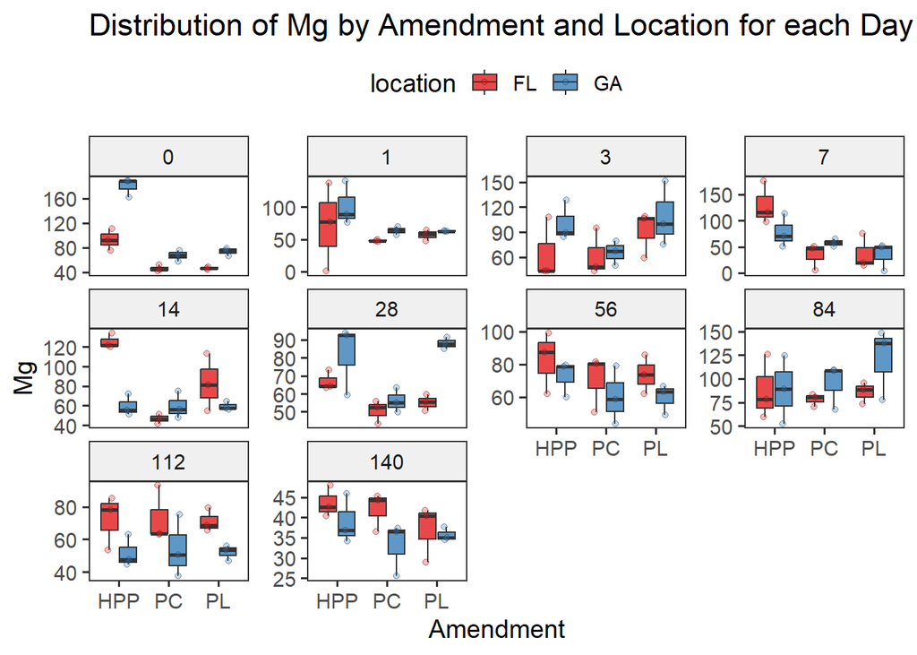

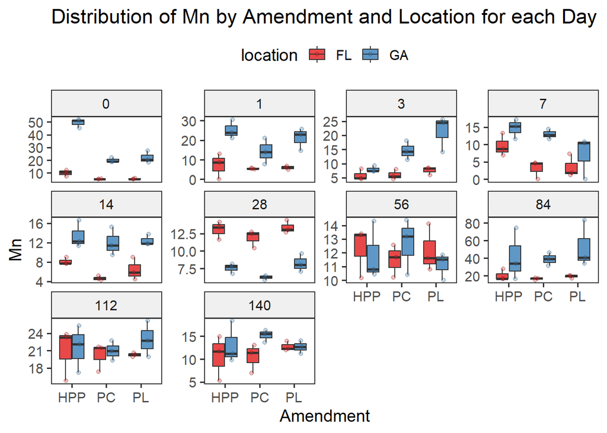

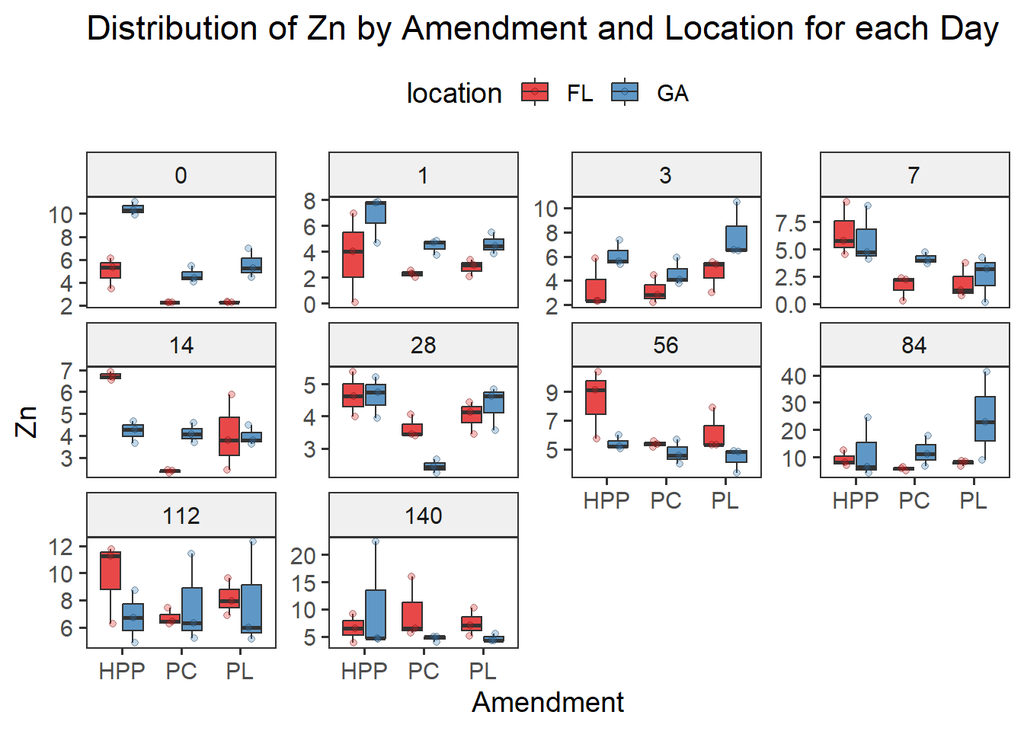

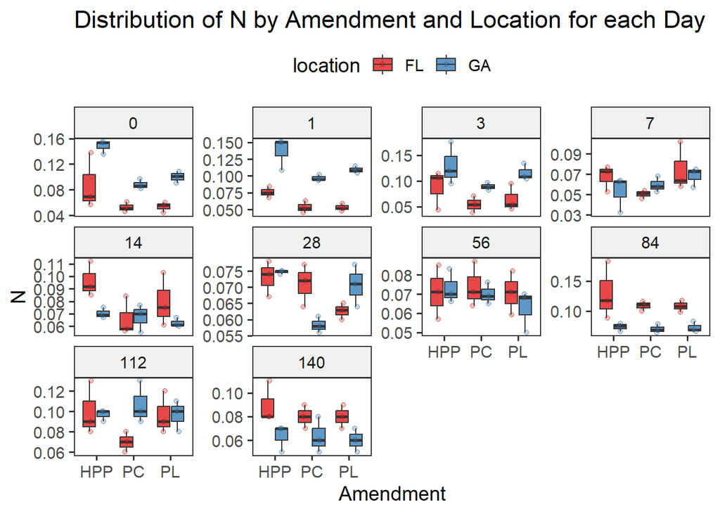

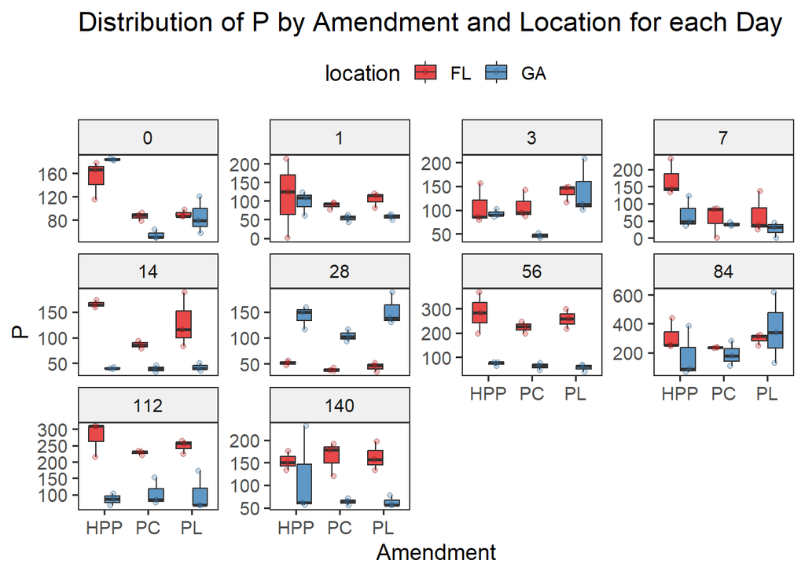

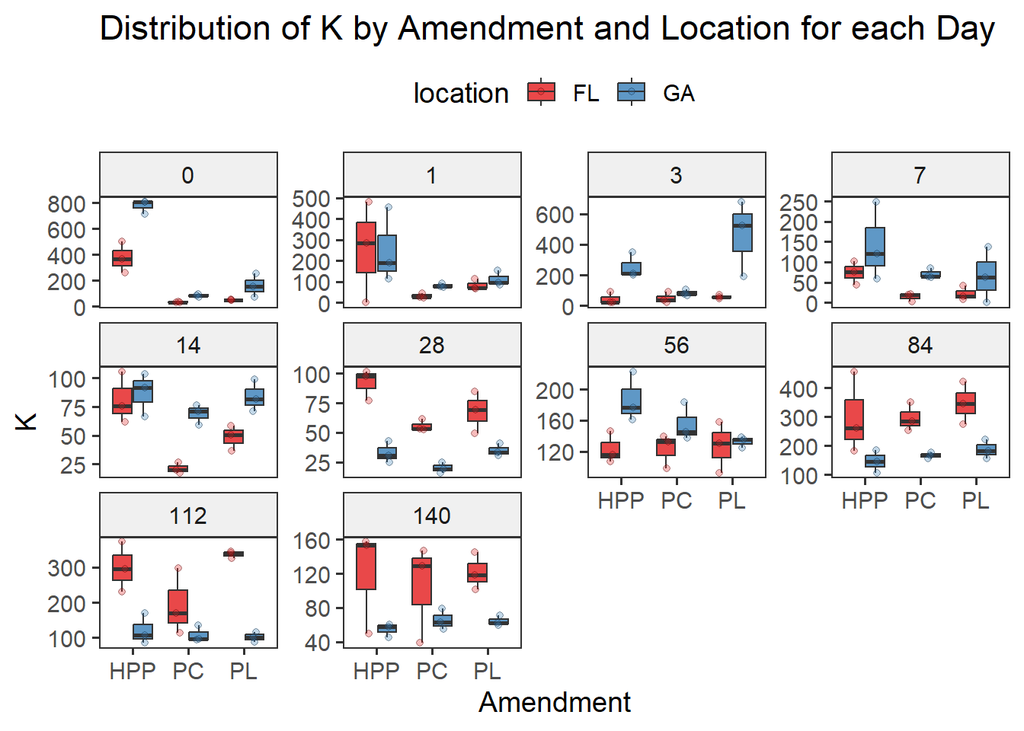

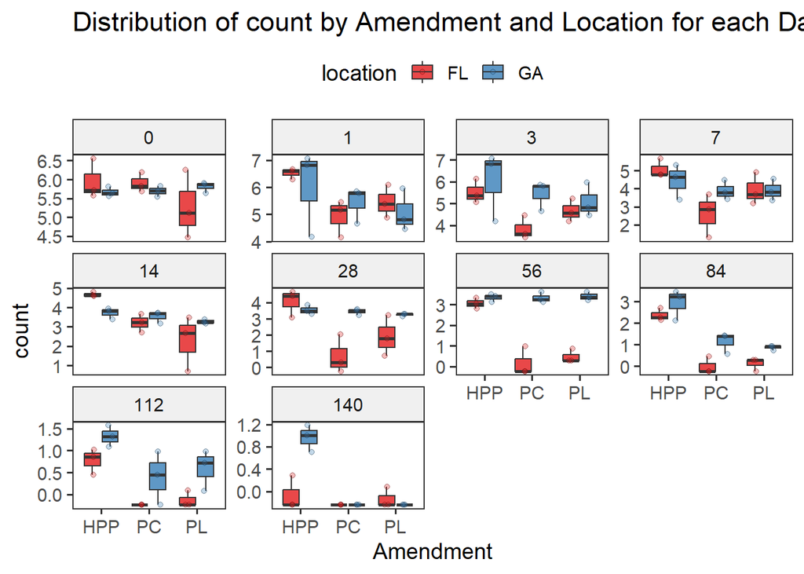

```r
# Exploratory Data Analysis (EDA)

# Set theme
theme_pub <- theme_bw(base_size = 14) +
  theme(panel.grid = element_blank(),
        strip.background = element_rect(fill = "#f0f0f0"),
        legend.position = "top")

# explore
nutrients <- c("pH", "SM", "EC", "Ca", "Mg", "Mn", "Zn", "N", "P", "K", "count")

# Plot nutrient distributions by amendment and location per day
for (nutrient in nutrients) {
  p <- ggplot(data, aes_string(x = "ammendment", y = nutrient, fill = "location")) +
    geom_boxplot(outlier.shape = NA, alpha = 0.8) +
    geom_jitter(position = position_jitterdodge(jitter.width = 0.2), alpha = 0.3, shape = 21) +
    facet_wrap(~day, scales = "free_y") +
    labs(title = paste("Distribution of", nutrient, "by Amendment and Location for each Day"),
         x = "Amendment", y = nutrient) +
    scale_fill_brewer(palette = "Set1") +
    theme_pub
  print(p)
}
```

```r
## Let's try some iterations
library(nlme)
library(emmeans)
library(multcompView)

results_list <- list()

for (i in 6:ncol(data)) {
  soil_property <- colnames(data)[i]

  cat("Analyzing:", soil_property, "\n")

  formula <- as.formula(paste(soil_property, "~ day * ammendment * location"))

  m2 <- lme(formula, data = data,
            random = ~ 1 | rep_am,
            correlation = corAR1(form = ~ 1 | rep_am))

  anova_results <- anova(m2)
  cat("ANOVA results for", soil_property, "\n")
  print(anova_results) }
```

```
Analyzing: pH
ANOVA results for pH
                        numDF denDF  F-value p-value
(Intercept)                 1   108 32302.86  <.0001
day                         9   108    66.79  <.0001
ammendment                  2    12     4.97  0.0268
location                    1    12     5.02  0.0448
day:ammendment             18   108     3.37  <.0001
day:location                9   108    17.95  <.0001
ammendment:location         2    12     0.64  0.5466
day:ammendment:location    18   108     1.75  0.0414
Analyzing: K
ANOVA results for K
                        numDF denDF  F-value p-value
(Intercept)                 1   108 715.9371  <.0001
day                         9   108  21.2726  <.0001
ammendment                  2    12  30.7103  <.0001
location                    1    12   1.7022  0.2165
day:ammendment             18   108  12.3999  <.0001
day:location                9   108  16.0740  <.0001
ammendment:location         2    12   0.6933  0.5189
day:ammendment:location    18   108   2.8661  0.0004
Analyzing: Mg
ANOVA results for Mg
                        numDF denDF   F-value p-value
(Intercept)                 1   108 1747.4428  <.0001
day                         9   108    9.3526  <.0001
ammendment                  2    12   21.4342  0.0001
location                    1    12    1.7108  0.2154
day:ammendment             18   108    4.4355  <.0001
day:location                9   108    5.1138  <.0001
ammendment:location         2    12    0.2222  0.8040
day:ammendment:location    18   108    2.0591  0.0121
Analyzing: Mn
ANOVA results for Mn
                        numDF denDF  F-value p-value
(Intercept)                 1   108 848.9915  <.0001
day                         9   108  25.2518  <.0001
ammendment                  2    12   3.1327  0.0804
location                    1    12  65.8195  <.0001
```

[output cut: 66 more lines]

```
day:ammendment             18   108    1.3393  0.1785
day:location                9   108    5.1189  <.0001
ammendment:location         2    12    0.0397  0.9612
day:ammendment:location    18   108    1.0852  0.3767
Analyzing: count
ANOVA results for count
                        numDF denDF   F-value p-value
(Intercept)                 1   108 2167.9011  <.0001
day                         9   108  124.9333  <.0001
ammendment                  2    12   27.6849  <.0001
location                    1    12   18.7172  0.0010
day:ammendment             18   108    2.4689  0.0022
day:location                9   108    5.5548  <.0001
ammendment:location         2    12    4.5270  0.0343
day:ammendment:location    18   108    2.4051  0.0029
```

```r
if (any(anova_results$`p-value` < 0.05, na.rm = TRUE)) { # Check if any factor is significant
    lsmeans_ammendment <- emmeans(m2, ~ location|day|ammendment)
    summary_lsmeans <- summary(lsmeans_ammendment)

    lsmeans_amendment_loc_day <- cld(lsmeans_ammendment,
                                     reversed = TRUE,
                                     adjust = "Bonferroni",
                                     Letters = letters)

    results_list[[soil_property]] <- list(
      anova = anova_results,
      lsmeans_summary = summary_lsmeans,
      lsmeans_cld = lsmeans_amendment_loc_day
    )
  }
## Only counts had all the factors being significant

results_list$count
```

```
$anova
                        numDF denDF   F-value p-value
(Intercept)                 1   108 2167.9011  <.0001
day                         9   108  124.9333  <.0001
ammendment                  2    12   27.6849  <.0001
location                    1    12   18.7172  0.0010
day:ammendment             18   108    2.4689  0.0022
day:location                9   108    5.5548  <.0001
ammendment:location         2    12    4.5270  0.0343
day:ammendment:location    18   108    2.4051  0.0029

$lsmeans_summary
day = 0, ammendment = HPP:
 location   emmean    SE df lower.CL upper.CL
 FL        5.95167 0.358 17   5.1962    6.707
 GA        5.66667 0.358 12   4.8865    6.447

day = 1, ammendment = HPP:
 location   emmean    SE df lower.CL upper.CL
 FL        6.51431 0.358 17   5.7588    7.270
 GA        6.02000 0.358 12   5.2398    6.800

day = 3, ammendment = HPP:
 location   emmean    SE df lower.CL upper.CL
 FL        5.51354 0.358 17   4.7580    6.269
 GA        6.02000 0.358 12   5.2398    6.800

day = 7, ammendment = HPP:
 location   emmean    SE df lower.CL upper.CL
 FL        5.08220 0.358 17   4.3267    5.838
 GA        4.43667 0.358 12   3.6565    5.217

day = 14, ammendment = HPP:
 location   emmean    SE df lower.CL upper.CL
 FL        4.67532 0.358 17   3.9198    5.431
 GA        3.71667 0.358 12   2.9365    4.497

day = 28, ammendment = HPP:
 location   emmean    SE df lower.CL upper.CL
 FL        4.05260 0.358 17   3.2971    4.808
```

[output cut: 268 more lines]

```
 GA        0.59333 0.358 12  -0.3234    1.510  a
 FL       -0.13169 0.358 12  -1.0484    0.785  a

day = 140, ammendment = PL:
 location   emmean    SE df lower.CL upper.CL .group
 FL       -0.13169 0.358 12  -1.0484    0.785  a
 GA       -0.24000 0.358 12  -1.1567    0.677  a

Degrees-of-freedom method: containment
Confidence level used: 0.95
Conf-level adjustment: bonferroni method for 2 estimates
significance level used: alpha = 0.05
NOTE: If two or more means share the same grouping symbol,
      then we cannot show them to be different.
      But we also did not show them to be the same.
```

Here, we will extract our residuals before concluding any inference from the means priorly extracted. Only E. coli count will be utilized for post-hoc means extraction and comparison.

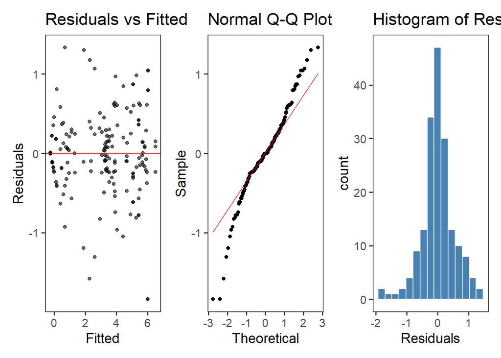

```r
# Residual diagnostics for counts
residuals_df <- augment(m2)


p1 <- ggplot(residuals_df, aes(.fitted, .resid)) +
  geom_point(alpha = 0.6) +
  geom_hline(yintercept = 0, color = "red") +
  labs(title = "Residuals vs Fitted", x = "Fitted", y = "Residuals") +
  theme_pub

p2 <- ggplot(residuals_df, aes(sample = .resid)) +
  stat_qq() + stat_qq_line(color = "red") +
  labs(title = "Normal Q-Q Plot", x = "Theoretical", y = "Sample") +
  theme_pub

p3 <- ggplot(residuals_df, aes(.resid)) +
  geom_histogram(bins = 15, fill = "steelblue", color = "white") +
  labs(title = "Histogram of Residuals", x = "Residuals") +
  theme_pub

p1 + p2 + p3
```

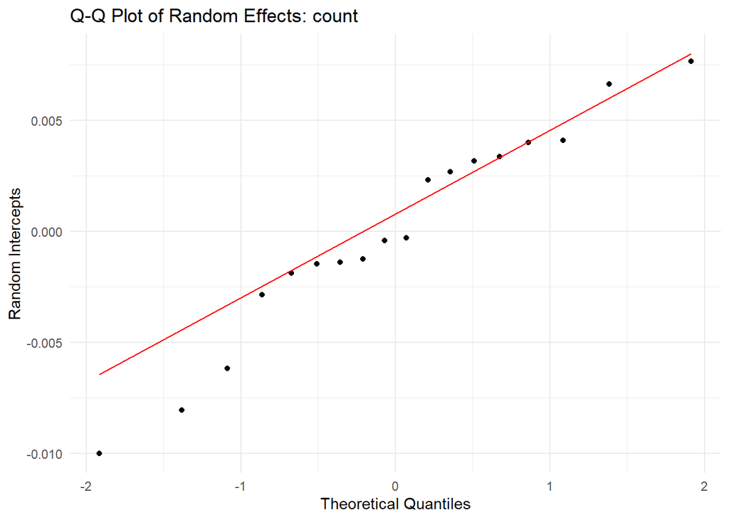

```r
# Fit model only for 'count'
soil_property <- "count"
model <- lme(count ~ day * ammendment * location,
             data = data,
             random = ~1 | rep_am,
             correlation = corAR1(form = ~1 | rep_am))

# Store model in a list
model_list <- list()
model_list[[soil_property]] <- model

# Plot Q-Q for random intercepts
for (soil_property in names(model_list)) {
  model <- model_list[[soil_property]]

  ranef_vals <- nlme::ranef(model)

  # Convert to data frame
  ranef_df <- data.frame(
    rep_am = rownames(ranef_vals),
    intercept = ranef_vals[, 1]
  )

  # Q-Q plot
  p <- ggplot(ranef_df, aes(sample = intercept)) +
    stat_qq() +
    stat_qq_line(color = "red") +
    labs(
      title = paste("Q-Q Plot of Random Effects:", soil_property),
      x = "Theoretical Quantiles",
      y = "Random Intercepts"
    ) +
    theme_minimal()

  print(p)
}
```

We can then make inferences, as the normality for random effects seems to be met.

```r
results_list$count
```

```
$anova
                        numDF denDF   F-value p-value
(Intercept)                 1   108 2167.9011  <.0001
day                         9   108  124.9333  <.0001
ammendment                  2    12   27.6849  <.0001
location                    1    12   18.7172  0.0010
day:ammendment             18   108    2.4689  0.0022
day:location                9   108    5.5548  <.0001
ammendment:location         2    12    4.5270  0.0343
day:ammendment:location    18   108    2.4051  0.0029

$lsmeans_summary
day = 0, ammendment = HPP:
 location   emmean    SE df lower.CL upper.CL
 FL        5.95167 0.358 17   5.1962    6.707
 GA        5.66667 0.358 12   4.8865    6.447

day = 1, ammendment = HPP:
 location   emmean    SE df lower.CL upper.CL
 FL        6.51431 0.358 17   5.7588    7.270
 GA        6.02000 0.358 12   5.2398    6.800

day = 3, ammendment = HPP:
 location   emmean    SE df lower.CL upper.CL
 FL        5.51354 0.358 17   4.7580    6.269
 GA        6.02000 0.358 12   5.2398    6.800

day = 7, ammendment = HPP:
 location   emmean    SE df lower.CL upper.CL
 FL        5.08220 0.358 17   4.3267    5.838
 GA        4.43667 0.358 12   3.6565    5.217

day = 14, ammendment = HPP:
 location   emmean    SE df lower.CL upper.CL
 FL        4.67532 0.358 17   3.9198    5.431
 GA        3.71667 0.358 12   2.9365    4.497

day = 28, ammendment = HPP:
 location   emmean    SE df lower.CL upper.CL
 FL        4.05260 0.358 17   3.2971    4.808
```

[output cut: 268 more lines]

```
 GA        0.59333 0.358 12  -0.3234    1.510  a
 FL       -0.13169 0.358 12  -1.0484    0.785  a

day = 140, ammendment = PL:
 location   emmean    SE df lower.CL upper.CL .group
 FL       -0.13169 0.358 12  -1.0484    0.785  a
 GA       -0.24000 0.358 12  -1.1567    0.677  a

Degrees-of-freedom method: containment
Confidence level used: 0.95
Conf-level adjustment: bonferroni method for 2 estimates
significance level used: alpha = 0.05
NOTE: If two or more means share the same grouping symbol,
      then we cannot show them to be different.
      But we also did not show them to be the same.
```

For instance, the effect of time (day), location and amendment types were found to significantly impact E. coli abundance at 99% confidence level. Therefore, the means will be extracted accordingly.

```r
lsmeans_ammendment <- emmeans(m2, ~ location|day|ammendment)
    summary_lsmeans <- summary(lsmeans_ammendment)

    lsmeans_amendment_loc_day <- cld(lsmeans_ammendment,
                                     reversed = TRUE,
                                     adjust = "Bonferroni",
                                     Letters = letters) %>%
  as.data.frame() %>%
  mutate(letter=trimws(.group))
    lsmeans_amendment_loc_day
```

```
   location day ammendment       emmean        SE df    lower.CL  upper.CL
2        FL   0        HPP  5.951668569 0.3580888 17  5.07146802 6.8318691
1        GA   0        HPP  5.666666667 0.3580888 12  4.74994742 6.5833859
22       FL   0         PC  5.904963900 0.3580888 12  4.98824465 6.8216831
21       GA   0         PC  5.693333333 0.3580888 12  4.77661409 6.6100526
41       GA   0         PL  5.806666667 0.3580888 12  4.88994742 6.7233859
42       FL   0         PL  5.279268344 0.3580888 12  4.36254910 6.1959876
4        FL   1        HPP  6.514306053 0.3580888 17  5.63410551 7.3945066
3        GA   1        HPP  6.020000000 0.3580888 12  5.10328075 6.9367192
23       GA   1         PC  5.430000000 0.3580888 12  4.51328075 6.3467192
24       FL   1         PC  4.920622537 0.3580888 12  4.00390329 5.8373418
44       FL   1         PL  5.448034035 0.3580888 12  4.53131479 6.3647533
43       GA   1         PL  5.076666667 0.3580888 12  4.15994742 5.9933859
5        GA   3        HPP  6.020000000 0.3580888 12  5.10328075 6.9367192
6        FL   3        HPP  5.513542878 0.3580888 17  4.63334233 6.3937434
```

[output cut: 107 more lines]

Let’s make our final plot with the letters

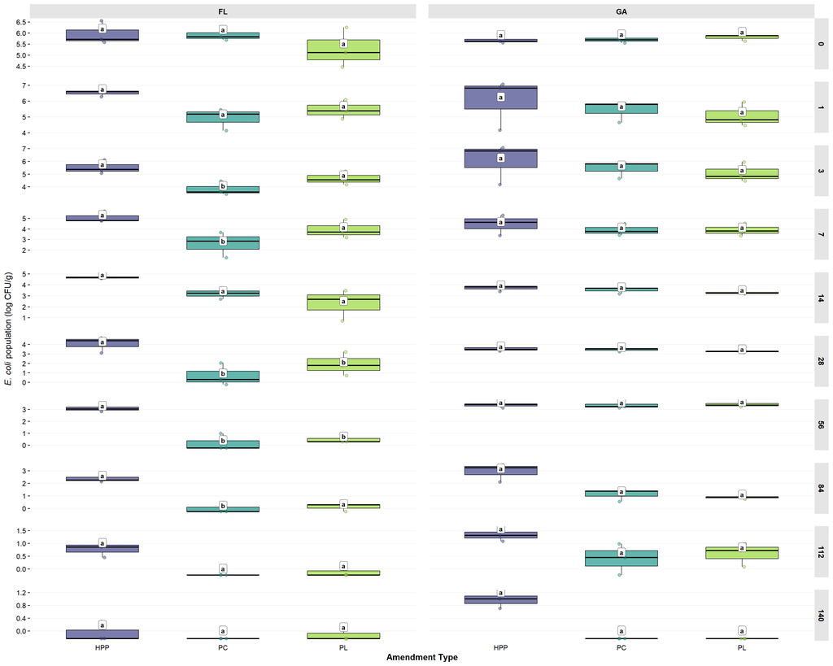

# 6 Team work in GitHub

Whether you are working with your future-self or as duos, make sure to stage, commit, and push after finishing each of the sub-sections above. When committing, write commit messages that are short and descriptive (e.g., finished wrangling).

If you are working in duos, make sure to split the workload. I will check your collaborative work through the commit history, and if one student has contributed significantly more than the other, than that will impact grades.

**Tip 1**: to avoid merge conflicts, make sure to **pull** first, and then start working locally. That will ensure that any changes made by your partner will be “downloaded” before you make changes to the files locally.

**Tip 2**: make use of the Issues on this repository to set up to-do lists and assign tasks to different people. You can also use each issue/task to discuss how things should be run and get to an agreement.

# 7 Submitting your work

Once you have developed all the code and answers, make sure to Render this quarto file.

**Notes on rendering**:

- Make sure to render your work and inspect how the final html look like.
- If it does not look professional for whatever reason, then fix the issue, re-render it, recheck.
- Only send me your work once your html file looks professional.
- Some potential issues you may encounter and how to fix them:
  - Some times your code may be creating a table output that is waaay to long and cumbersome to scroll through when rendered. If this is the case, make it more professional looking by using the `head()` function to only print the first handful of rows (instead of thousands of rows).
  - **DO NOT** delete the file’s heading levels (# and ##). They set up the proper heading 1 and 2 levels, and I use them to guide my grading.
  - If a given chunk is also outputting warnings or messages, inhibit this behavior by changing the chunk options `message` and `warning` to `FALSE`.
  - If, after rendered, 2 lines of text are connected and you wish to “break line” between them, add 2 extra spaces after the first one.

After rendering, an .html file will be created on your `code` folder.

Rename this file to `LASTNAME1-LASTNAME2_finalproject.html`.  
For ex., `Bastos-Mendes_finalproject.html`.

Submit the html file on eLC by **April 30th** 11:59 pm.